# uro_cons_t3

Andrew Villeneuve

5/28/2020

# The Study

For this part of the study, we measured the consumption rate of juvenile Urosalpinx cinerea . We placed snails in tea strainers within two days of hatching, and grew them in tea strainers separated by population for 24 days. Nine replicates per population were distributed in six temperatures, with three groups of three subreplicates in each temperature/population treatment. Each snail was given five oysters at the beginning of the experiment, and over three different timepoints we checked strainers for number of oysters consumed and added new oysters. While the time between checking and adding oysters differed, time between checking for each snail was recorded. In some cases, all oysters were consumed, and in this case we noted this and removed the snails from analysis (see silenced code for this). Here, we will analyze only the rate of consumption at the third timepoint, as differences between populations at t1 and t2 were minimal. At time point 3, all snails had been in the experiment for 10-13 days and ranged from 12-15 days old. We stopped recording consumption rate after 10-13 days and simply added oysters to fuel their growth.

## Metadata

### TPC.Label

Unique code for each indiviudal snail, corresponding to population, temperature treatment

### tank.replicate

Bin number (1-3), sub-replication in each temperature treatment.

### Population

Source population of each snail

### Temp

One of six common garden temperatures. 24 days exposure in degrees C

### Date Hatch

Date of juvenile hatching

### Date TPC

Date of juvenile placement in TPC common garden experiment. Within two days of Date Hatch

### timepoint

We measured consumption three times in the course of the common garden experiment. This indicates at which point we recorded this.

### date.feed

The date that we checked oysters for consumption and added new ones. Also the date of each timepoint.

### no.consumed

The number of oysters consumed, indicated by a clear drill hole in the shell of an oyster. Oysters in the process of being drilled were not counted.

### duration

The number of days since the last date.feed.

### rate

The rate of oysters consumed per day, calculated as (no.consumed)/(duration)

### all.consumed

Whether all oysters were consumed in the course of the timepoint duration, in other words, did the snails run out of food? y/n

### Environmental Data

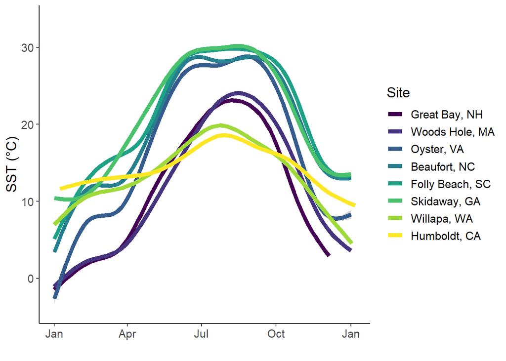

```
##      site quantile   decile      max     mean summer.mean seasonlength10
## 1     gbj 22.91100 23.69700 25.96300 12.40097    20.88969            179
## 2      wh 23.60000 24.30000 26.00000 12.10044    21.35360            197
## 3      oy 28.92496 30.07281 33.56934 17.08424    27.54020            250
## 4      bf 29.10000 29.80000 31.00000 19.73769    28.28414            330
## 5      fb 29.80000 30.00000 31.30000 20.34944    29.12126            310
## 6 nah1516 19.80700 20.43960 26.49120 13.91728    18.73544            285
## 7    hmi2 18.77000 19.78000 21.80000 14.43312    17.36318            348
## 8     to3 22.14730 22.71100 24.12180 17.90621    20.91789            366
## 9    gcsk 30.26200 30.97800 33.47800 21.45739    29.36123            348
##   seasonlength16
## 1            137
## 2            132
## 3            186
## 4            224
## 5            214
## 6            123
## 7            113
## 8            224
## 9            237
```

# Data Exploration

Below, we can see why we focus on t3. A wider range of consumption rates. As a result, I will filter out timepoints 1 and 2 and keep t3 observations only.

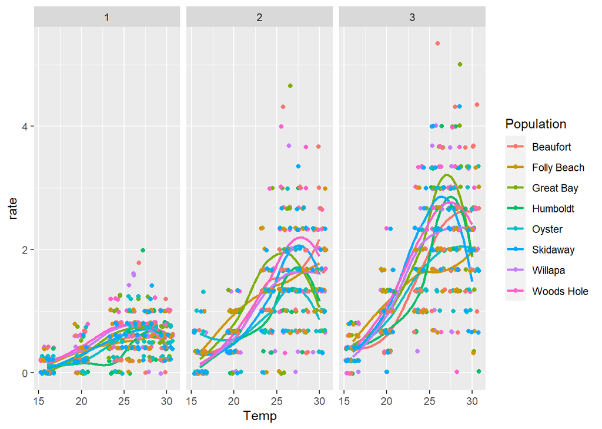

Below is basic data exploration. Are the number consumed and rate zero-inflated? Potentially.We will have to use a poisson model clearly.

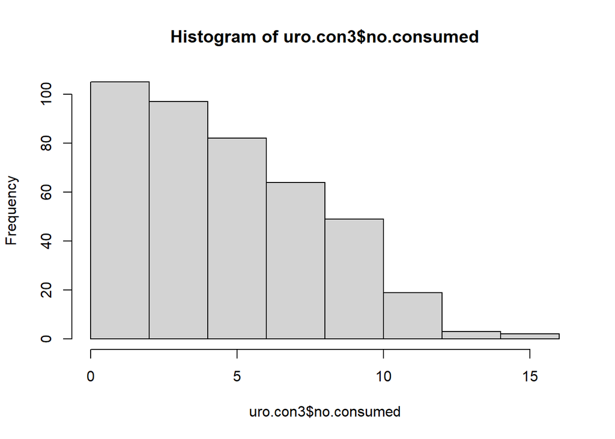

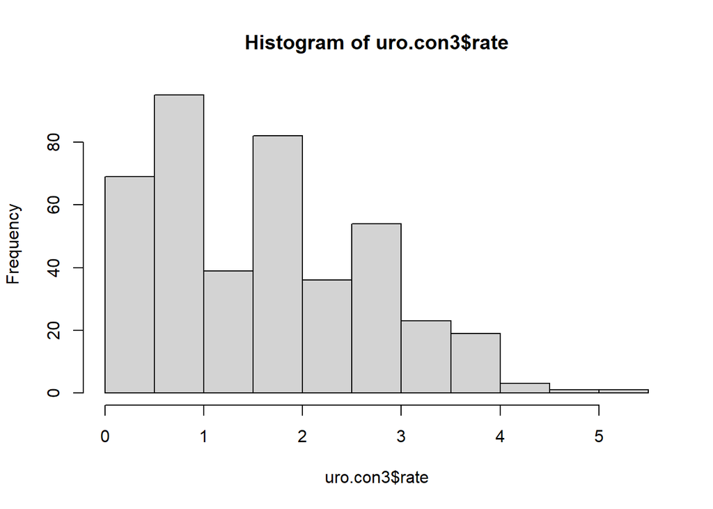

## Residuals of a full model

Below are analyses of several types of models that should model consumption rate over temperature and population. I used a poisson error distribution and a log transformed offset of duration to the number consumed to get the rate. I used the log of no.consumption partially because this is what Cheng et al. 2017 did.

I check each of these models to test for overdispersion (and further zero inflation models below). I can fix overdispersion, but the behavior of the residuals seem to be difficult to solve.

```r
full<-glmmTMB(no.consumed ~ Population *Temp  + (1|tank.replicate), uro.con3, family = "poisson",offset=(log(duration)))

fullz <-glmmTMB(no.consumed ~ Population *Temp  + (1|tank.replicate), uro.con3, family = "poisson",offset=(log(duration)),ziformula=~1)

fullzOLRE<-glmmTMB(no.consumed ~ Population *Temp  +(1|tank.replicate)+(1|TPC.Label), uro.con3, family = "poisson",offset=(log(duration)),ziformula=~1)

binomzOLRE<-glmmTMB(no.consumed ~ Population *Temp  + (1|tank.replicate)+(1|TPC.Label), uro.con3, family = "nbinom1",offset=(log(duration)),ziformula=~1)
binomz<-glmmTMB(no.consumed ~ Population *Temp  +(1|tank.replicate), uro.con3, family = "nbinom1",offset=(log(duration)),ziformula=~1)

binomzOLRE2<-glmmTMB(no.consumed ~ Population *Temp  + (1|tank.replicate)+(1|TPC.Label), uro.con3, family = "nbinom2",offset=(log(duration)),ziformula=~1)
binomz2<-glmmTMB(no.consumed ~ Population *Temp  +(1|tank.replicate), uro.con3, family = "nbinom2",offset=(log(duration)),ziformula=~1)

fullOLRE<-glmmTMB(no.consumed ~ Population *Temp  + (1|tank.replicate)+(1|TPC.Label), uro.con3, family = "poisson",offset=(log(duration)))

binomOLRE<-glmmTMB(no.consumed ~ Population *Temp  + (1|tank.replicate)+(1|TPC.Label), uro.con3, family = "nbinom1",offset=(log(duration)))
binom<-glmmTMB(no.consumed ~ Population *Temp  +(1|tank.replicate), uro.con3, family = "nbinom1",offset=(log(duration)))

binomOLRE2<-glmmTMB(no.consumed ~ Population *Temp  + (1|tank.replicate)+(1|TPC.Label), uro.con3, family = "nbinom2",offset=(log(duration)))
binom2<-glmmTMB(no.consumed ~ Population *Temp  +(1|tank.replicate), uro.con3, family = "nbinom2",offset=(log(duration)))


bbmle::AICctab(full,fullz,fullzOLRE,binomzOLRE,binomz,binomzOLRE2,binomz2,fullOLRE,binomOLRE,binom,binomOLRE2,binom2)
```

```
##             dAICc df
## fullzOLRE    0.0  19
## binomz2      0.2  19
## binomzOLRE2  2.5  20
## binom2       2.9  18
## fullOLRE     3.0  18
## binomOLRE2   5.1  19
## binomz       6.5  19
## fullz        8.8  18
## binom       11.3  18
## full        16.5  17
## binomzOLRE    NA  20
## binomOLRE     NA  19
```

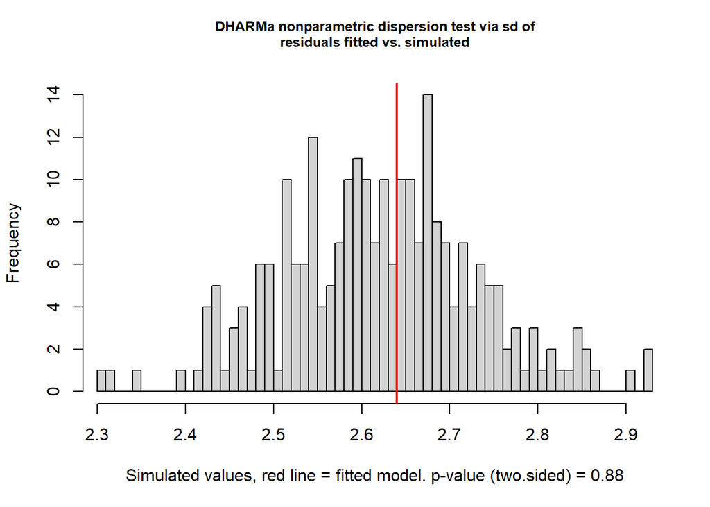

```
##
##  DHARMa nonparametric dispersion test via sd of residuals fitted vs.
##  simulated
##
## data:  simulationOutput
## ratioObsSim = 1.0075, p-value = 0.88
## alternative hypothesis: two.sided
```

```r
#up in the air whether zero inflated helps.




sim_full<-simulateResiduals(fullzOLRE)
testDispersion(sim_full) #no overdispersion
```

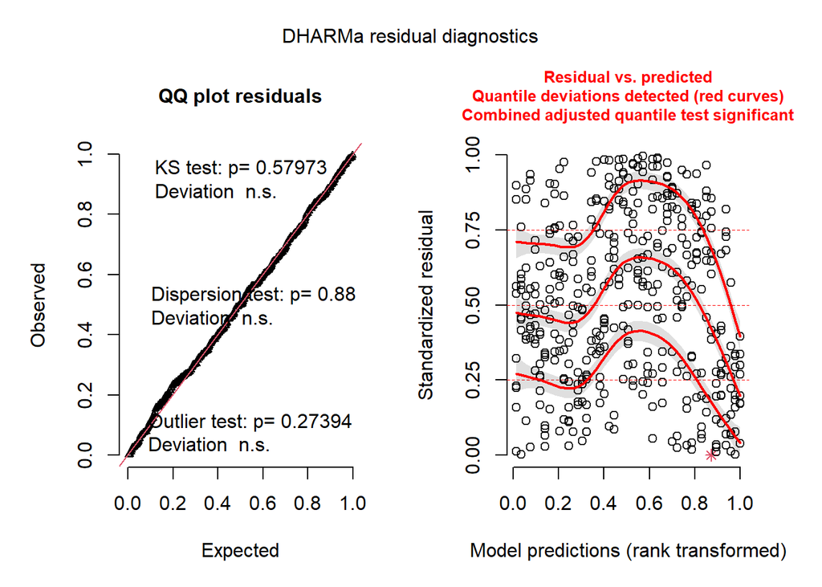

```r
plot(sim_full) # but look at those patterns in the quantiles of residuals v. predicted
```

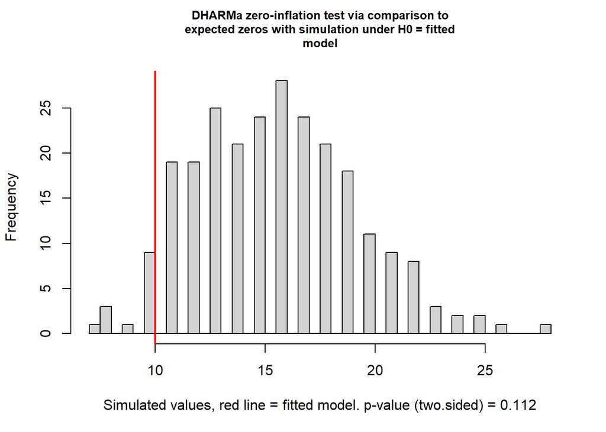

```
##
##  DHARMa zero-inflation test via comparison to expected zeros with
##  simulation under H0 = fitted model
##
## data:  simulationOutput
## ratioObsSim = 0.63646, p-value = 0.112
## alternative hypothesis: two.sided
```

```r
testZeroInflation(sim_full)
```

```r
#doesn't look zero inflated, but we need to directly compare

summary(binomz2)
```

```
##  Family: nbinom2  ( log )
## Formula:          no.consumed ~ Population * Temp + (1 | tank.replicate)
## Zero inflation:               ~1
## Data: uro.con3
##  Offset: (log(duration))
##
##      AIC      BIC   logLik deviance df.resid
##   1932.1   2008.9   -947.0   1894.1      402
##
## Random effects:
##
## Conditional model:
##  Groups         Name        Variance  Std.Dev.
##  tank.replicate (Intercept) 2.969e-10 1.723e-05
## Number of obs: 421, groups:  tank.replicate, 3
##
## Overdispersion parameter for nbinom2 family (): 22.8
##
## Conditional model:
##                             Estimate Std. Error z value Pr(>|z|)
## (Intercept)                -2.989086   0.428193  -6.981 2.94e-12 ***
## PopulationFolly Beach       1.237525   0.581678   2.128   0.0334 *
## PopulationGreat Bay         0.872484   0.593486   1.470   0.1415
## PopulationHumboldt         -0.074165   0.619023  -0.120   0.9046
## PopulationOyster            0.421940   0.608667   0.693   0.4882
## PopulationSkidaway          1.005752   0.578883   1.737   0.0823 .
## PopulationWillapa           0.258627   0.603729   0.428   0.6684
## PopulationWoods Hole        0.567957   0.579841   0.980   0.3273
## Temp                        0.137933   0.016357   8.433  < 2e-16 ***
## PopulationFolly Beach:Temp -0.053550   0.022512  -2.379   0.0174 *
## PopulationGreat Bay:Temp   -0.028777   0.022762  -1.264   0.2061
## PopulationHumboldt:Temp     0.002673   0.023752   0.113   0.9104
## PopulationOyster:Temp      -0.021503   0.023346  -0.921   0.3570
## PopulationSkidaway:Temp    -0.036637   0.022314  -1.642   0.1006
## PopulationWillapa:Temp     -0.009271   0.023108  -0.401   0.6883
## PopulationWoods Hole:Temp  -0.015843   0.022290  -0.711   0.4772
## ---
## Signif. codes:  0 '***' 0.001 '**' 0.01 '*' 0.05 '.' 0.1 ' ' 1
##
## Zero-inflation model:
##             Estimate Std. Error z value Pr(>|z|)
## (Intercept)   -5.230      0.792  -6.603 4.02e-11 ***
## ---
## Signif. codes:  0 '***' 0.001 '**' 0.01 '*' 0.05 '.' 0.1 ' ' 1
```

Let’s test for zero-inflation

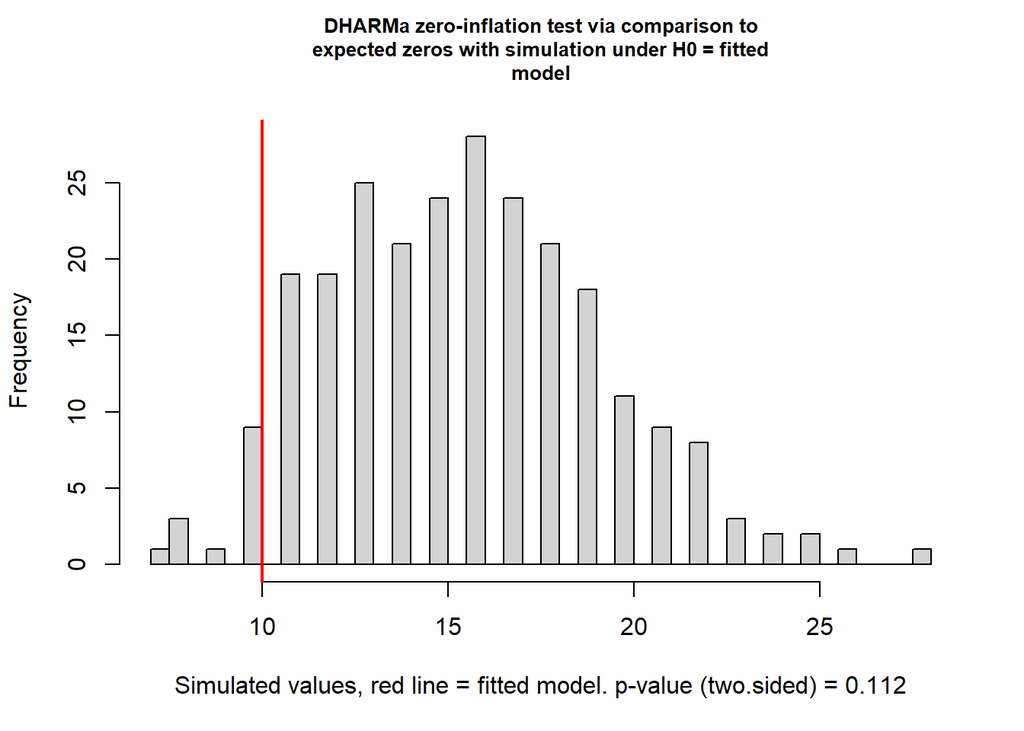

```
##
##  DHARMa zero-inflation test via comparison to expected zeros with
##  simulation under H0 = fitted model
##
## data:  simulationOutput
## ratioObsSim = 0.63646, p-value = 0.112
## alternative hypothesis: two.sided
```

```r
testZeroInflation(sim_full)
```

```r
#doesn't look zero inflated, but we need to directly compare

bbmle::AICctab(full,fullz,fullzOLRE,binomzOLRE,binomz,binomzOLRE2,binomz2,fullOLRE,binomOLRE,binom,binomOLRE2,binom2)
```

```
##             dAICc df
## fullzOLRE    0.0  19
## binomz2      0.2  19
## binomzOLRE2  2.5  20
## binom2       2.9  18
## fullOLRE     3.0  18
## binomOLRE2   5.1  19
## binomz       6.5  19
## fullz        8.8  18
## binom       11.3  18
## full        16.5  17
## binomzOLRE    NA  20
## binomOLRE     NA  19
```

```r
#up in the air whether zero inflated helps.
```

# Create Broken Stick Regressions

All of those models are a mess. Really,I just need to have segmented create broken stick models.

```r
bf<-filter(uro.con3,Population=="Beaufort")
fb<-filter(uro.con3,Population=="Folly Beach")
gb<-filter(uro.con3,Population=="Great Bay")
hm<-filter(uro.con3,Population=="Humboldt")
oy<-filter(uro.con3,Population=="Oyster")
sk<-filter(uro.con3,Population=="Skidaway")
wp<-filter(uro.con3,Population=="Willapa")
wh<-filter(uro.con3,Population=="Woods Hole")

m.wh<-glm(no.consumed~Temp,wh,family=nbinom2,offset=log(duration))
seg.wh<-segmented(m.wh,seg.Z = ~Temp, psi=24)

m.gb<-glm(no.consumed~Temp,gb,family=nbinom2,offset=log(duration))
seg.gb<-segmented(m.gb,seg.Z = ~Temp, psi=24)

m.oy<-glm(no.consumed~Temp,oy,family=nbinom2,offset=log(duration))
seg.oy<-segmented(m.oy,seg.Z = ~Temp, psi=24)

m.bf<-glm(no.consumed~Temp,bf,family=nbinom2,offset=log(duration))
seg.bf<-segmented(m.bf,seg.Z = ~Temp, psi=29,seg.control(maxit.glm=15),fix.npsi=T,n.boot=50)
m.fb<-glm(no.consumed~Temp,fb,family=nbinom2,offset=log(duration))
seg.fb<-segmented(m.fb,seg.Z = ~Temp, psi=24)
m.sk<-glm(no.consumed~Temp,sk,family=nbinom2,offset=log(duration))
seg.sk<-segmented(m.sk,seg.Z = ~Temp, psi=24)

m.hm<-glm(no.consumed~Temp,hm,family=nbinom2,offset=log(duration))
seg.hm<-segmented(m.hm,seg.Z = ~Temp, psi=24)
```

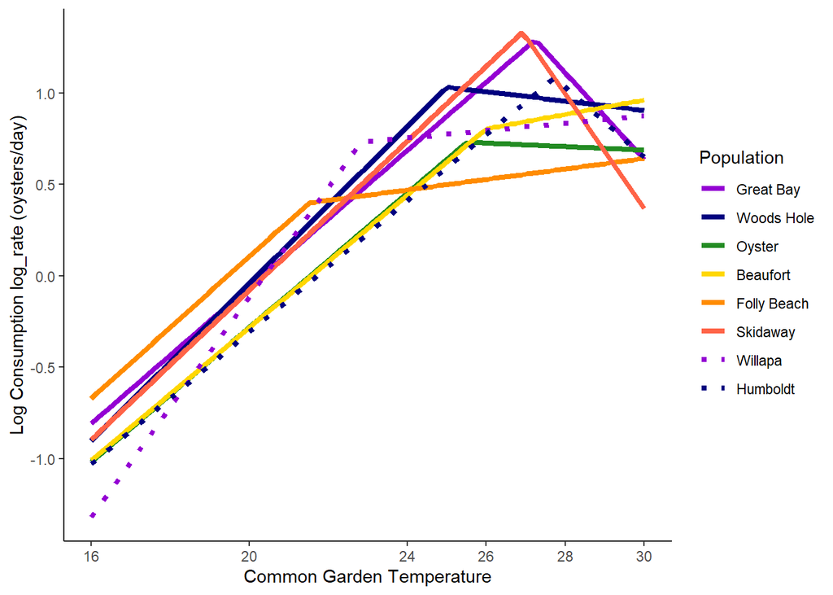

```r
m.wp<-glm(no.consumed~Temp,wp,family=nbinom2,offset=log(duration))
seg.wp<-segmented(m.wp,seg.Z = ~Temp, psi=24)

xmin<-min(uro.con3$Temp,na.rm=T)
xmax<-max(uro.con3$Temp,na.rm=T)

all.length.seg<-list(seg.gb,seg.wh,seg.oy,seg.bf,seg.fb,seg.sk,seg.wp,seg.hm)


##plotting predicted values
predicted.gb<-data.frame(Temp=seq(xmin,xmax,length.out=100))
predicted.gb$log_rate<-predict(seg.gb,predicted.gb)
predicted.gb$pop<-"gb"
predicted.gb$oce<-"a"

predicted.wh<-data.frame(Temp=seq(xmin,xmax,length.out=100))
predicted.wh$log_rate<-predict(seg.wh,predicted.wh)
predicted.wh$pop<-"wh"
predicted.wh$oce<-"a"

predicted.oy<-data.frame(Temp=seq(xmin,xmax,length.out=100))
predicted.oy$log_rate<-predict(seg.oy,predicted.oy)
predicted.oy$pop<-"oy"
predicted.oy$oce<-"a"

predicted.bf<-data.frame(Temp=seq(xmin,xmax,length.out=100))
predicted.bf$log_rate<-predict(seg.bf,predicted.bf)
predicted.bf$pop<-"bf"
predicted.bf$oce<-"a"

predicted.fb<-data.frame(Temp=seq(xmin,xmax,length.out=100))
predicted.fb$log_rate<-predict(seg.fb,predicted.fb)
predicted.fb$pop<-"fb"
predicted.fb$oce<-"a"

predicted.sk<-data.frame(Temp=seq(xmin,xmax,length.out=100))
predicted.sk$log_rate<-predict(seg.sk,predicted.sk)
predicted.sk$pop<-"sk"
predicted.sk$oce<-"a"

predicted.wp<-data.frame(Temp=seq(xmin,xmax,length.out=100))
predicted.wp$log_rate<-predict(seg.wp,predicted.wp)
predicted.wp$pop<-"wp"
predicted.wp$oce<-"p"

predicted.hm<-data.frame(Temp=seq(xmin,xmax,length.out=100))
predicted.hm$log_rate<-predict(seg.hm,predicted.hm)
predicted.hm$pop<-"hm"
predicted.hm$oce<-"p"

all.cons.pred<-rbind(predicted.gb,predicted.wh,predicted.oy,predicted.bf,predicted.fb,predicted.sk,predicted.wp,predicted.hm)
all.cons.pred$pop<-factor(all.cons.pred$pop,levels=c("gb","wh","oy","bf","fb","sk","wp","hm"))
all.cons.pred$Population<-ifelse(all.cons.pred$pop=="gb","Great Bay",ifelse(all.cons.pred$pop=="wh","Woods Hole",ifelse(all.cons.pred$pop=="oy","Oyster",ifelse(all.cons.pred$pop=="bf","Beaufort",ifelse(all.cons.pred$pop=="fb","Folly Beach",ifelse(all.cons.pred$pop=="sk","Skidaway",ifelse(all.cons.pred$pop=="wp","Willapa",ifelse(all.cons.pred$pop=="hm","Humboldt",NA))))))))
all.cons.pred$Population<-as.factor(all.cons.pred$Population)
all.cons.pred$Population<-factor(all.cons.pred$Population,levels=c("Great Bay","Woods Hole","Oyster","Beaufort","Folly Beach","Skidaway","Willapa","Humboldt"))


uro.con$lograte<-log(uro.con$rate)
uro.con$Population<-factor(uro.con$Population,levels=c("Great Bay","Woods Hole","Oyster","Beaufort","Folly Beach","Skidaway","Willapa","Humboldt"))


ggplot(all.cons.pred,aes(x=Temp,y=log_rate,group=pop))+geom_line(aes(group=pop,color=pop,linetype=pop),size=1.5)+
  ylab("Log Consumption log_rate (oysters/day)")+xlab("Common Garden Temperature")+theme_classic()+
  scale_linetype_manual(values=c(1,1,1,1,1,1,3,3),labels=c("Great Bay","Woods Hole","Oyster","Beaufort","Folly Beach","Skidaway","Willapa","Humboldt"),name="Population")+
  scale_color_manual(values=c("dark violet","navy","forest green","gold","dark orange","tomato","dark violet","navy"),labels=c("Great Bay","Woods Hole","Oyster","Beaufort","Folly Beach","Skidaway","Willapa","Humboldt"),name="Population")+scale_x_continuous(breaks=c(16,20,24,26,28,30))
```

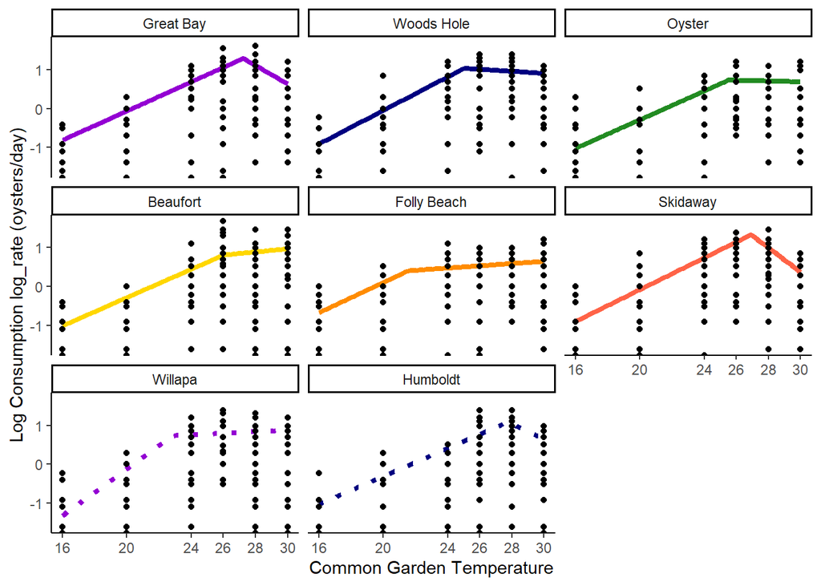

```r
ggplot(all.cons.pred,aes(x=Temp,y=log_rate,group=Population))+geom_line(aes(group=Population,color=Population,linetype=Population),size=1.5)+
   ylab("Log Consumption log_rate (oysters/day)")+xlab("Common Garden Temperature")+theme_classic()+
   scale_linetype_manual(values=c(1,1,1,1,1,1,3,3),labels=c("Great Bay","Woods Hole","Oyster","Beaufort","Folly Beach","Skidaway","Willapa","Humboldt"),name="Population")+
   scale_color_manual(values=c("dark violet","navy","forest green","gold","dark orange","tomato","dark violet","navy"),labels=c("Great Bay","Woods Hole","Oyster","Beaufort","Folly Beach","Skidaway","Willapa","Humboldt"),name="Population")+scale_x_continuous(breaks=c(16,20,24,26,28,30))+
   geom_point(data=uro.con,aes(x=Temp,y=lograte,group=Population))+facet_wrap(Population~.)+theme(legend.position = "none")
```

#Breakpoints (incomplete)

# Breakpoint analysis

## Breakpoint, y

```r
   ###################################3
   #y point (trait performance)
  #brkpts_con<-filter(brkpts_con,pop!="Skidaway")

   mods.brk_con<-list(
  "nullo"=glm(brkpty~1,brkpts_con,family="gaussian"),
  "lato"=glm(brkpty~lat+oce,brkpts_con,family="gaussian"),
  "meano"=glm(brkpty~mean+oce,brkpts_con,family="gaussian"),
  "s.meano"=glm(brkpty~s.mean+oce,brkpts_con,family="gaussian"),
  "q.meano"=glm(brkpty~q.mean+oce,brkpts_con,family="gaussian"),
  "t.meano"=glm(brkpty~t.mean+oce,brkpts_con,family="gaussian"),
  "seasonlengtho10"=glm(brkpty~seasonlength10+oce,brkpts_con,family="gaussian"),
  "seasonlengtho16"=glm(brkpty~seasonlength16+oce,brkpts_con,family="gaussian"),
  "maxo"=glm(brkpty~max+oce,brkpts_con,family="gaussian"),
  "lat"=glm(brkpty~lat,brkpts_con,family="gaussian"),
  "mean"=glm(brkpty~mean,brkpts_con,family="gaussian"),
  "s.mean"=glm(brkpty~s.mean,brkpts_con,family="gaussian"),
  "q.mean"=glm(brkpty~q.mean,brkpts_con,family="gaussian"),
  "t.mean"=glm(brkpty~t.mean,brkpts_con,family="gaussian"),
  "seasonlength10"=glm(brkpty~seasonlength10,brkpts_con,family="gaussian"),
  "seasonlength16"=glm(brkpty~seasonlength16,brkpts_con,family="gaussian"),
  "omax"=glm(brkpty~max,brkpts_con,family="gaussian"),
  "o*lat"=glm(brkpty~lat*oce,brkpts_con,family="gaussian"),
  "o*mean"=glm(brkpty~mean*oce,brkpts_con,family="gaussian"),
  "o*s.mean"=glm(brkpty~s.mean*oce,brkpts_con,family="gaussian"),
  "o*q.mean"=glm(brkpty~q.mean*oce,brkpts_con,family="gaussian"),
  "o*t.mean"=glm(brkpty~t.mean*oce,brkpts_con,family="gaussian"),
  "o*seasonlength10"=glm(brkpty~seasonlength10*oce,brkpts_con,family="gaussian"),
  "seasonlength16"=glm(brkpty~seasonlength16*oce,brkpts_con,family="gaussian"),
  "o*max"=glm(brkpty~max*oce,brkpts_con,family="gaussian")
  )


aictab(mods.brk_con)
```

```
##
## Model selection based on AICc:
##
##                  K  AICc Delta_AICc AICcWt Cum.Wt    LL
## nullo            2  9.68       0.00   0.48   0.48 -1.64
## mean             3 11.04       1.36   0.25   0.73  0.48
## s.mean           3 14.59       4.92   0.04   0.77 -1.30
## omax             3 14.64       4.96   0.04   0.81 -1.32
## q.mean           3 14.79       5.11   0.04   0.85 -1.39
## t.mean           3 14.88       5.20   0.04   0.89 -1.44
## seasonlength16   3 14.97       5.30   0.03   0.92 -1.49
## seasonlength10   3 15.06       5.38   0.03   0.95 -1.53
## lat              3 15.06       5.38   0.03   0.99 -1.53
## meano            4 17.31       7.63   0.01   1.00  2.01
## q.meano          4 22.71      13.03   0.00   1.00 -0.69
## t.meano          4 23.05      13.38   0.00   1.00 -0.86
## maxo             4 23.19      13.51   0.00   1.00 -0.93
## s.meano          4 23.71      14.04   0.00   1.00 -1.19
## seasonlengtho16  4 23.92      14.25   0.00   1.00 -1.29
## lato             4 24.16      14.48   0.00   1.00 -1.41
## seasonlengtho10  4 24.39      14.71   0.00   1.00 -1.53
## o*mean           5 34.53      24.86   0.00   1.00  2.73
## o*q.mean         5 40.69      31.02   0.00   1.00 -0.35
## o*t.mean         5 40.96      31.29   0.00   1.00 -0.48
## o*lat            5 41.25      31.58   0.00   1.00 -0.63
## o*max            5 41.63      31.95   0.00   1.00 -0.82
## o*s.mean         5 41.64      31.96   0.00   1.00 -0.82
## seasonlength16   5 41.87      32.20   0.00   1.00 -0.94
## o*seasonlength10 5 41.94      32.26   0.00   1.00 -0.97
```

```r
   summary(lm(brkpty~mean,brkpts_con))
```

```
##
## Call:
## lm(formula = brkpty ~ mean, data = brkpts_con)
##
## Residuals:
##     Min      1Q  Median      3Q     Max
## -0.3333 -0.2358  0.0735  0.1535  0.3395
##
## Coefficients:
##             Estimate Std. Error t value Pr(>|t|)
## (Intercept)  1.82356    0.44819   4.069  0.00659 **
## mean        -0.05460    0.02668  -2.047  0.08664 .
## ---
## Signif. codes:  0 '***' 0.001 '**' 0.01 '*' 0.05 '.' 0.1 ' ' 1
##
## Residual standard error: 0.2631 on 6 degrees of freedom
## Multiple R-squared:  0.4111, Adjusted R-squared:  0.313
## F-statistic: 4.189 on 1 and 6 DF,  p-value: 0.08664
```

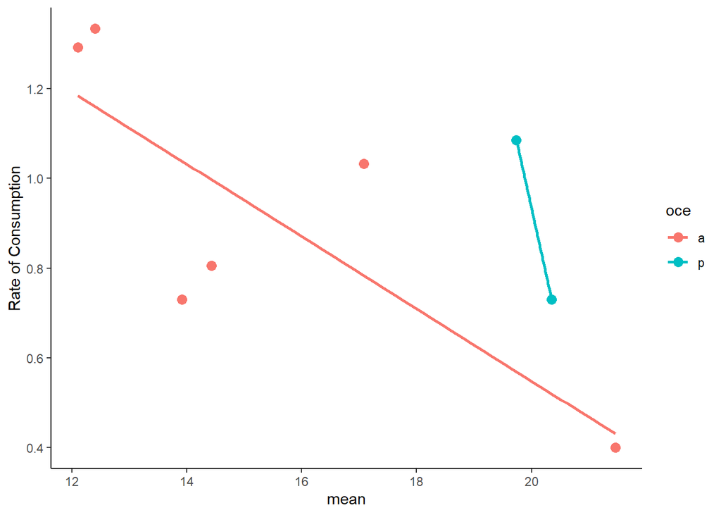

```r
   ggplot(brkpts_con,aes(x=mean,y=brkpty,color=oce,fill=oce),group=oce)+
      geom_point(size=3)+theme_classic()+geom_smooth(method="lm",se=F)+ylab(label="Rate of Consumption")
```

```r
     ###############################################3
   #x point (t opt)
   mods.brk_con<-list(
  "nullo"=glm(brkptx~1,brkpts_con,family="gaussian"),
  "lato"=glm(brkptx~lat+oce,brkpts_con,family="gaussian"),
  "meano"=glm(brkptx~mean+oce,brkpts_con,family="gaussian"),
  "s.meano"=glm(brkptx~s.mean+oce,brkpts_con,family="gaussian"),
  "q.meano"=glm(brkptx~q.mean+oce,brkpts_con,family="gaussian"),
  "t.meano"=glm(brkptx~t.mean+oce,brkpts_con,family="gaussian"),
  "seasonlengtho10"=glm(brkptx~seasonlength10+oce,brkpts_con,family="gaussian"),
  "seasonlengtho16"=glm(brkptx~seasonlength16+oce,brkpts_con,family="gaussian"),
  "maxo"=glm(brkptx~max+oce,brkpts_con,family="gaussian"),
  "lat"=glm(brkptx~lat,brkpts_con,family="gaussian"),
  "mean"=glm(brkptx~mean,brkpts_con,family="gaussian"),
  "s.mean"=glm(brkptx~s.mean,brkpts_con,family="gaussian"),
  "q.mean"=glm(brkptx~q.mean,brkpts_con,family="gaussian"),
  "t.mean"=glm(brkptx~t.mean,brkpts_con,family="gaussian"),
  "seasonlength10"=glm(brkptx~seasonlength10,brkpts_con,family="gaussian"),
  "seasonlength16"=glm(brkptx~seasonlength16,brkpts_con,family="gaussian"),
  "omax"=glm(brkptx~max,brkpts_con,family="gaussian"),
  "o*lat"=glm(brkptx~lat*oce,brkpts_con,family="gaussian"),
  "o*mean"=glm(brkptx~mean*oce,brkpts_con,family="gaussian"),
  "o*s.mean"=glm(brkptx~s.mean*oce,brkpts_con,family="gaussian"),
  "o*q.mean"=glm(brkptx~q.mean*oce,brkpts_con,family="gaussian"),
  "o*t.mean"=glm(brkptx~t.mean*oce,brkpts_con,family="gaussian"),
  "o*seasonlength10"=glm(brkptx~seasonlength10*oce,brkpts_con,family="gaussian"),
  "seasonlength16"=glm(brkptx~seasonlength16*oce,brkpts_con,family="gaussian"),
  "o*max"=glm(brkptx~max*oce,brkpts_con,family="gaussian")
  )

   aictab(mods.brk_con)
```

```
##
## Model selection based on AICc:
##
##                  K  AICc Delta_AICc AICcWt Cum.Wt     LL
## nullo            2 40.53       0.00   0.43   0.43 -17.07
## mean             3 41.54       1.00   0.26   0.69 -14.77
## s.mean           3 43.64       3.11   0.09   0.78 -15.82
## omax             3 45.67       5.14   0.03   0.81 -16.84
## q.mean           3 45.91       5.37   0.03   0.84 -16.95
## t.mean           3 46.00       5.47   0.03   0.87 -17.00
## o*mean           5 46.02       5.48   0.03   0.90  -3.01
## seasonlength16   3 46.02       5.48   0.03   0.93 -17.01
## lat              3 46.13       5.59   0.03   0.95 -17.06
## seasonlength10   3 46.13       5.60   0.03   0.98 -17.07
## meano            4 46.88       6.34   0.02   1.00 -12.77
## s.meano          4 51.61      11.07   0.00   1.00 -15.14
## maxo             4 54.53      13.99   0.00   1.00 -16.60
## q.meano          4 54.67      14.14   0.00   1.00 -16.67
## t.meano          4 55.00      14.46   0.00   1.00 -16.83
## seasonlengtho16  4 55.22      14.69   0.00   1.00 -16.94
## lato             4 55.44      14.91   0.00   1.00 -17.06
## seasonlengtho10  4 55.46      14.93   0.00   1.00 -17.07
## o*s.mean         5 64.32      23.79   0.00   1.00 -12.16
## o*lat            5 69.41      28.87   0.00   1.00 -14.70
## o*q.mean         5 69.71      29.18   0.00   1.00 -14.86
## o*t.mean         5 70.01      29.48   0.00   1.00 -15.01
## o*seasonlength10 5 70.23      29.69   0.00   1.00 -15.11
## seasonlength16   5 70.31      29.78   0.00   1.00 -15.16
## o*max            5 70.40      29.86   0.00   1.00 -15.20
```

```r
   summary(lm(brkptx~mean,brkpts_con))
```

```
##
## Call:
## lm(formula = brkptx ~ mean, data = brkpts_con)
##
## Residuals:
##     Min      1Q  Median      3Q     Max
## -1.8788 -0.8659 -0.1019  0.0655  3.6763
##
## Coefficients:
##             Estimate Std. Error t value Pr(>|t|)
## (Intercept)  31.7067     3.0150  10.516 4.34e-05 ***
## mean         -0.3874     0.1795  -2.159   0.0742 .
## ---
## Signif. codes:  0 '***' 0.001 '**' 0.01 '*' 0.05 '.' 0.1 ' ' 1
##
## Residual standard error: 1.77 on 6 degrees of freedom
## Multiple R-squared:  0.4371, Adjusted R-squared:  0.3433
## F-statistic: 4.659 on 1 and 6 DF,  p-value: 0.07423
```

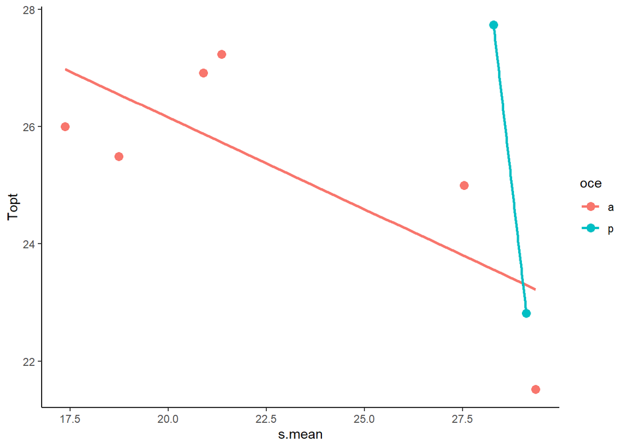

```r
   ggplot(brkpts_con,aes(x=s.mean,y=brkptx,color=oce,fill=oce),group=oce)+
      geom_point(size=3)+theme_classic()+geom_smooth(method="lm",se=F)+ylab(label="Topt")
```

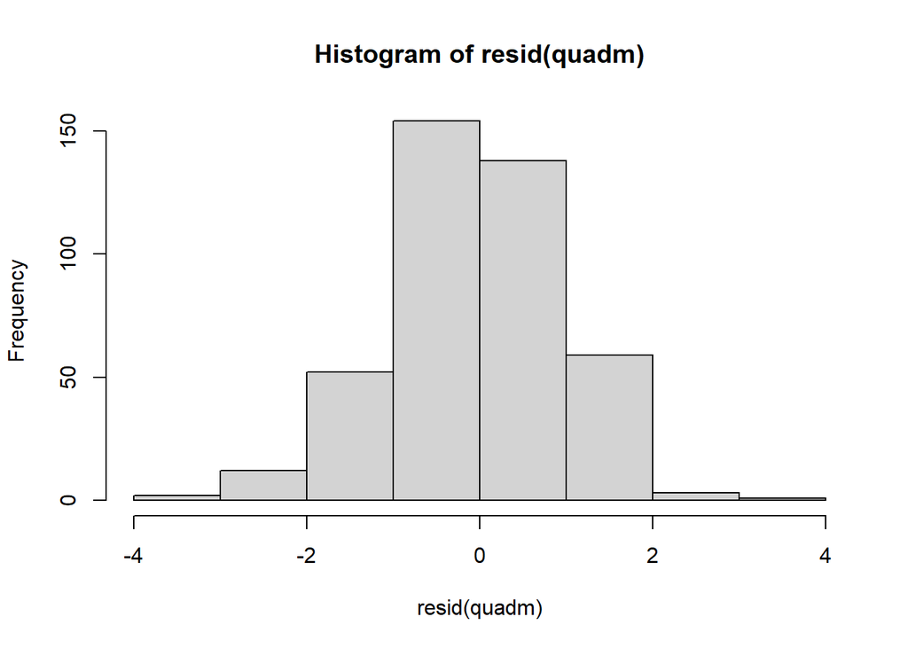

```r
   #####################################################################################
   #################################################################################
   ##Quadratic

   quadm<-(glm(no.consumed~poly(uro.con3$Temp,2)+Population,uro.con3,family=poisson,offset=log(duration)))
   hist(resid(quadm))
```

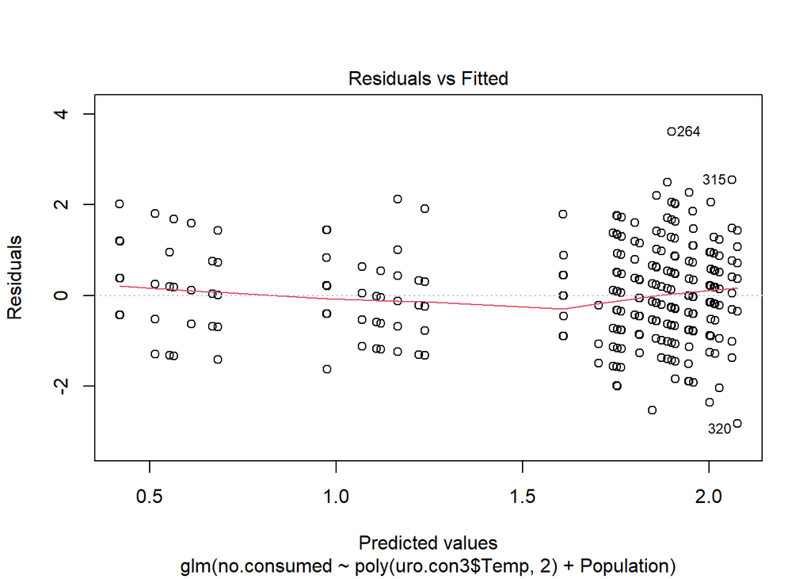

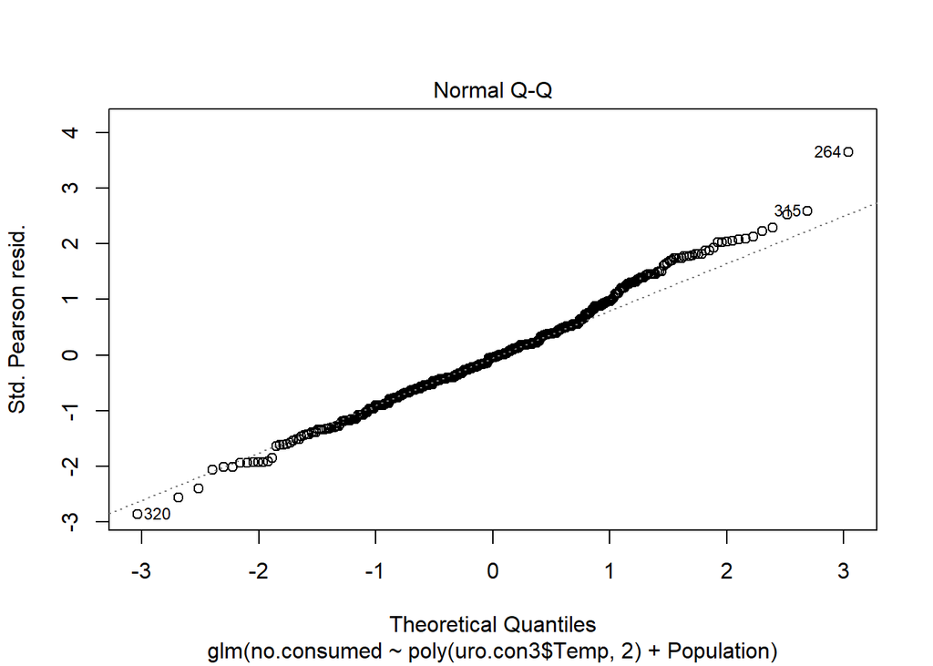

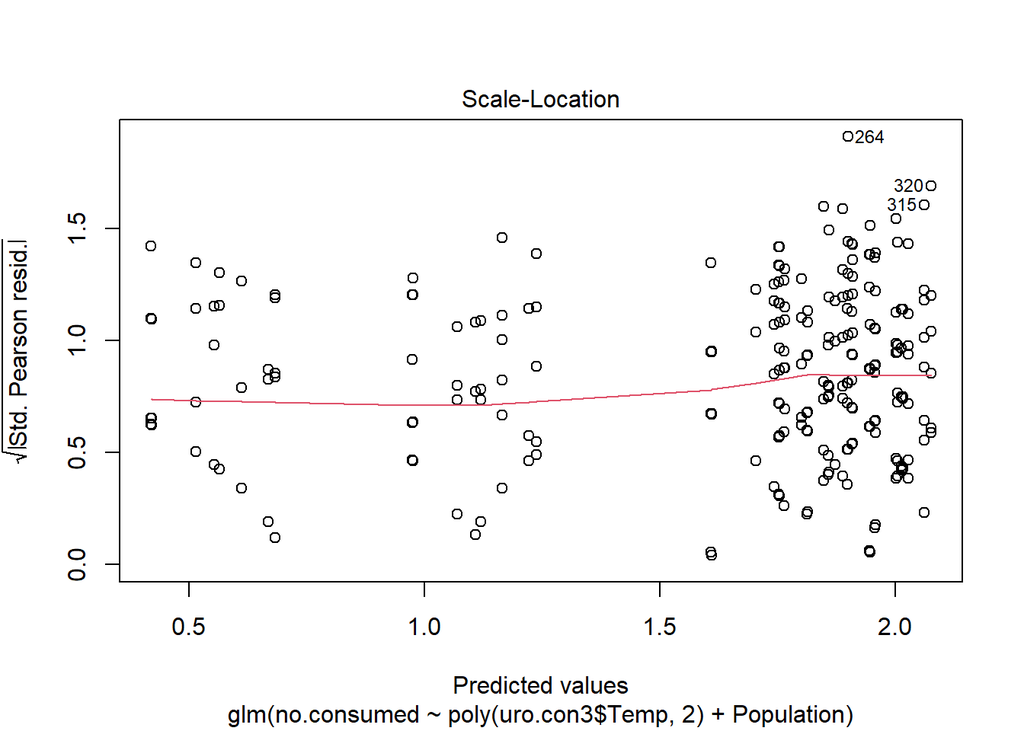

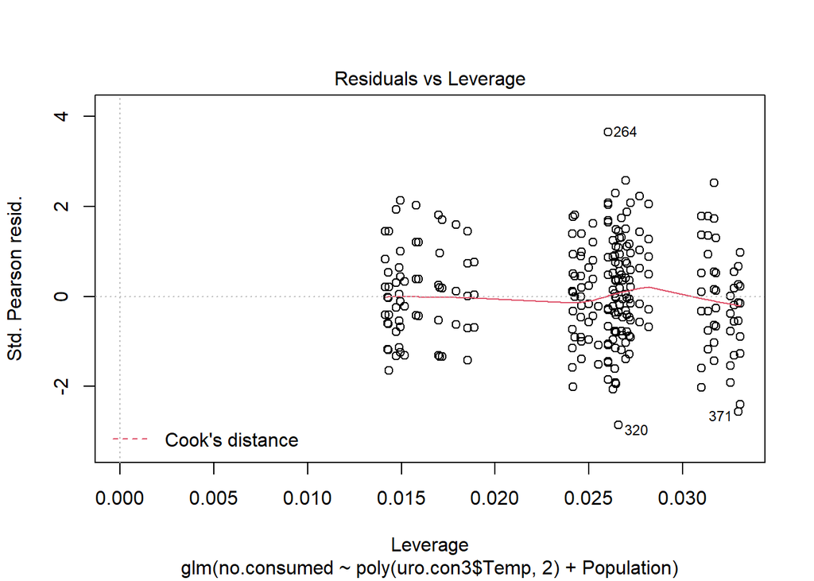

```r
   plot(quadm)
```

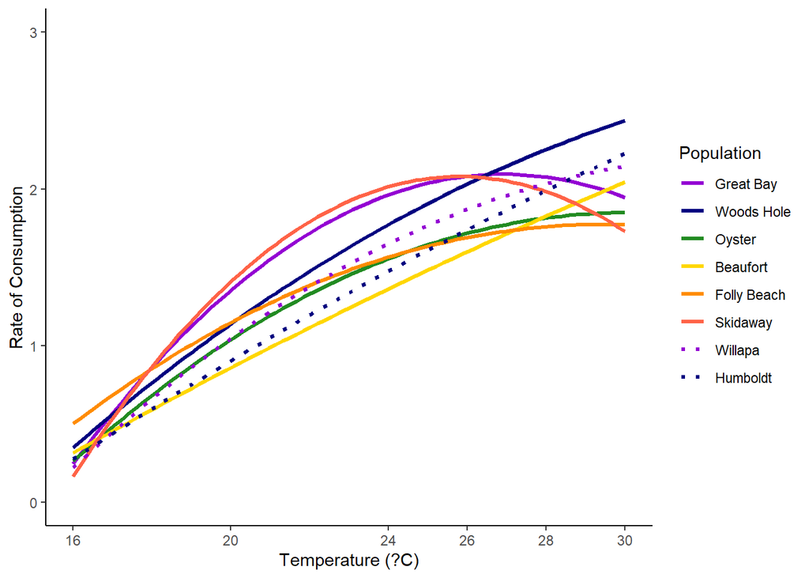

```r
   bf<-filter(uro.con3,Population=="Beaufort")
   fb<-filter(uro.con3,Population=="Folly Beach")
   gb<-filter(uro.con3,Population=="Great Bay")
   hm<-filter(uro.con3,Population=="Humboldt")
   oy<-filter(uro.con3,Population=="Oyster")
   sk<-filter(uro.con3,Population=="Skidaway")
   wp<-filter(uro.con3,Population=="Willapa")
   wh<-filter(uro.con3,Population=="Woods Hole")

   xminq<-min(poly(uro.con3$Temp,2),na.rm=T)
   xmaxq<-max(poly(uro.con3$Temp,2),na.rm=T)

   qmgb<-(glm(no.consumed~poly(gb$Temp,2,raw=T),gb,family=poisson,offset=log(duration)))
   cfgb<-coef(qmgb)
   brkpts_con[3,11]<-(-cfgb[2]/(2*(cfgb[3])))
   brkpts_con[3,12]<-cfgb[1]+cfgb[2]*brkpts_con[3,11]+cfgb[3]*(brkpts_con[3,11]^2)

   qmwh<-(glm(no.consumed~poly(wh$Temp,2,raw=T),wh,family=poisson,offset=log(duration)))
   cfwh<-coef(qmwh)
   brkpts_con[4,11]<-(-cfwh[2]/(2*(cfwh[3])))
   brkpts_con[4,12]<-cfwh[1]+cfwh[2]*brkpts_con[4,11]+cfwh[3]*(brkpts_con[4,11]^2)

   qmoy<-(glm(no.consumed~poly(oy$Temp,2,raw=T),oy,family=poisson,offset=log(duration)))
   cfoy<-coef(qmoy)
   brkpts_con[5,11]<-(-cfoy[2]/(2*(cfoy[3])))
   brkpts_con[5,12]<-cfoy[1]+cfoy[2]*brkpts_con[5,11]+cfoy[3]*(brkpts_con[5,11]^2)

   qmbf<-(glm(no.consumed~poly(bf$Temp,2,raw=T),bf,family=poisson,offset=log(duration)))
   cfbf<-coef(qmbf)
   brkpts_con[6,11]<-(-cfbf[2]/(2*(cfbf[3])))
   brkpts_con[6,12]<-cfbf[1]+cfbf[2]*brkpts_con[6,11]+cfbf[3]*(brkpts_con[6,11]^2)


   qmfb<-(glm(no.consumed~poly(fb$Temp,2,raw=T),fb,family=poisson,offset=log(duration)))
   cffb<-coef(qmfb)
   brkpts_con[7,11]<-(-cffb[2]/(2*(cffb[3])))
   brkpts_con[7,12]<-cffb[1]+cffb[2]*brkpts_con[7,11]+cffb[3]*(brkpts_con[7,11]^2)

   qmsk<-(glm(no.consumed~poly(sk$Temp,2,raw=T),sk,family=poisson,offset=log(duration)))
   cfsk<-coef(qmsk)
   brkpts_con[8,11]<-(-cfsk[2]/(2*(cfsk[3])))
   brkpts_con[8,12]<-cfsk[1]+cfsk[2]*brkpts_con[8,11]+cfsk[3]*(brkpts_con[8,11]^2)

   qmwp<-(glm(no.consumed~poly(wp$Temp,2,raw=T),wp,family=poisson,offset=log(duration)))
   cfwp<-coef(qmwp)
   brkpts_con[1,11]<-(-cfwp[2]/(2*(cfwp[3])))
   brkpts_con[1,12]<-cfwp[1]+cfwp[2]*brkpts_con[1,11]+cfwp[3]*(brkpts_con[1,11]^2)

   qmhm<-(glm(no.consumed~poly(hm$Temp,2,raw=T),hm,family=poisson,offset=log(duration)))
   cfhm<-coef(qmhm)
   brkpts_con[2,11]<-(-cfhm[2]/(2*(cfhm[3])))
   brkpts_con[2,12]<-cfhm[1]+cfhm[2]*brkpts_con[2,11]+cfhm[3]*(brkpts_con[2,11]^2)


   uro.con3$Population<-factor(uro.con3$Population,levels=c("Great Bay","Woods Hole","Oyster","Beaufort","Folly Beach","Skidaway","Willapa","Humboldt"))

   #poisson graph - not a good visual
  # ggplot(uro.con3,aes(y=no.consumed,x=Temp,group=Population,color=Population,linetype=Population))+
  #   scale_x_continuous(breaks=c(16,20,24,26,28,30))+
  #    scale_color_manual(values=c("dark violet","navy","forest green","gold","dark orange","tomato","dark violet","navy"),labels=c("Great Bay","Woods Hole","Oyster","Beaufort","Folly Beach","Skidaway","Willapa","Humboldt"),name="Population")+
  #    scale_linetype_manual(values=c(1,1,1,1,1,1,3,3),labels=c("Great Bay","Woods Hole","Oyster","Beaufort","Folly Beach","Skidaway","Willapa","Humboldt"),name="Population")+
  #    scale_size_manual(values=c(1.2,1.2,1.2,1.2,1.2,1.2,1.2,1.2),labels=c("Great Bay","Woods Hole","Oyster","Beaufort","Folly Beach","Skidaway","Willapa","Humboldt"),name="Population")+
  #    theme_classic()+labs(y="Rate of Consumption",x="Temperature (?C)")+facet_wrap(Population~.)+geom_point()
   ggplot(uro.con3,aes(y=rate,x=Temp,group=Population,linetype=Population))+
      geom_smooth(method='glm',formula=y~poly(x,2),se=F,aes(color=Population,size=Population))+theme_classic()+
      scale_x_continuous(breaks=c(16,20,24,26,28,30))+
      scale_color_manual(values=c("dark violet","navy","forest green","gold","dark orange","tomato","dark violet","navy"),labels=c("Great Bay","Woods Hole","Oyster","Beaufort","Folly Beach","Skidaway","Willapa","Humboldt"),name="Population")+
      scale_linetype_manual(values=c(1,1,1,1,1,1,3,3),labels=c("Great Bay","Woods Hole","Oyster","Beaufort","Folly Beach","Skidaway","Willapa","Humboldt"),name="Population")+
      scale_size_manual(values=c(1.2,1.2,1.2,1.2,1.2,1.2,1.2,1.2),labels=c("Great Bay","Woods Hole","Oyster","Beaufort","Folly Beach","Skidaway","Willapa","Humboldt"),name="Population")+
      theme_classic()+labs(y="Rate of Consumption",x="Temperature (?C)")+scale_y_continuous(breaks=c(0,1,2,3),limits=c(0,3))
```

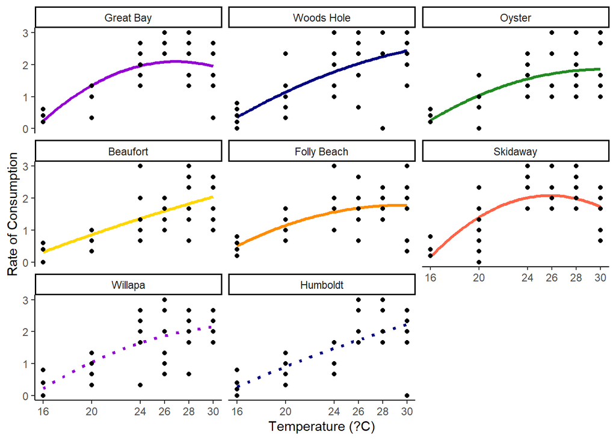

```r
   ggplot(uro.con3,aes(y=rate,x=Temp,group=Population,linetype=Population))+
      geom_smooth(method='glm',formula=y~poly(x,2),se=F,aes(color=Population,size=Population))+theme_classic()+
      scale_x_continuous(breaks=c(16,20,24,26,28,30))+
      scale_color_manual(values=c("dark violet","navy","forest green","gold","dark orange","tomato","dark violet","navy"),labels=c("Great Bay","Woods Hole","Oyster","Beaufort","Folly Beach","Skidaway","Willapa","Humboldt"),name="Population")+
      scale_linetype_manual(values=c(1,1,1,1,1,1,3,3),labels=c("Great Bay","Woods Hole","Oyster","Beaufort","Folly Beach","Skidaway","Willapa","Humboldt"),name="Population")+
      scale_size_manual(values=c(1.2,1.2,1.2,1.2,1.2,1.2,1.2,1.2),labels=c("Great Bay","Woods Hole","Oyster","Beaufort","Folly Beach","Skidaway","Willapa","Humboldt"),name="Population")+
      theme_classic()+labs(y="Rate of Consumption",x="Temperature (?C)")+facet_wrap(Population~.)+geom_point()+theme(legend.position = "none")+scale_y_continuous(breaks=c(0,1,2,3),limits=c(0,3))
```

```r
   mods.brkyq<-list(
    "nullo"=glm(brkptyq~1,brkpts_con,family="gaussian"),
  "lato"=glm(brkptyq~lat+oce,brkpts_con,family="gaussian"),
  "meano"=glm(brkptyq~mean+oce,brkpts_con,family="gaussian"),
  "s.meano"=glm(brkptyq~s.mean+oce,brkpts_con,family="gaussian"),
  "q.meano"=glm(brkptyq~q.mean+oce,brkpts_con,family="gaussian"),
  "t.meano"=glm(brkptyq~t.mean+oce,brkpts_con,family="gaussian"),
  "seasonlengtho10"=glm(brkptyq~seasonlength10+oce,brkpts_con,family="gaussian"),
  "seasonlengtho16"=glm(brkptyq~seasonlength16+oce,brkpts_con,family="gaussian"),
  "maxo"=glm(brkptyq~max+oce,brkpts_con,family="gaussian"),
  "lat"=glm(brkptyq~lat,brkpts_con,family="gaussian"),
  "mean"=glm(brkptyq~mean,brkpts_con,family="gaussian"),
  "s.mean"=glm(brkptyq~s.mean,brkpts_con,family="gaussian"),
  "q.mean"=glm(brkptyq~q.mean,brkpts_con,family="gaussian"),
  "t.mean"=glm(brkptyq~t.mean,brkpts_con,family="gaussian"),
  "seasonlength10"=glm(brkptyq~seasonlength10,brkpts_con,family="gaussian"),
  "seasonlength16"=glm(brkptyq~seasonlength16,brkpts_con,family="gaussian"),
  "omax"=glm(brkptyq~max,brkpts_con,family="gaussian"),
  "o*lat"=glm(brkptyq~lat*oce,brkpts_con,family="gaussian"),
  "o*mean"=glm(brkptyq~mean*oce,brkpts_con,family="gaussian"),
  "o*s.mean"=glm(brkptyq~s.mean*oce,brkpts_con,family="gaussian"),
  "o*q.mean"=glm(brkptyq~q.mean*oce,brkpts_con,family="gaussian"),
  "o*t.mean"=glm(brkptyq~t.mean*oce,brkpts_con,family="gaussian"),
  "o*seasonlength10"=glm(brkptyq~seasonlength10*oce,brkpts_con,family="gaussian"),
  "seasonlength16"=glm(brkptyq~seasonlength16*oce,brkpts_con,family="gaussian"),
  "o*max"=glm(brkptyq~max*oce,brkpts_con,family="gaussian")
  )

   aictab(mods.brkyq)
```

```
##
## Model selection based on AICc:
##
##                  K  AICc Delta_AICc AICcWt Cum.Wt   LL
## nullo            2 -2.06       0.00   0.58   0.58 4.23
## mean             3  1.22       3.28   0.11   0.69 5.39
## s.mean           3  2.23       4.28   0.07   0.76 4.89
## omax             3  3.17       5.23   0.04   0.80 4.41
## lat              3  3.21       5.27   0.04   0.84 4.40
## q.mean           3  3.31       5.37   0.04   0.88 4.35
## t.mean           3  3.33       5.39   0.04   0.92 4.33
## seasonlength10   3  3.50       5.56   0.04   0.96 4.25
## seasonlength16   3  3.51       5.57   0.04   0.99 4.24
## meano            4  9.39      11.45   0.00   1.00 5.97
## s.meano          4 11.10      13.16   0.00   1.00 5.12
## q.meano          4 11.84      13.90   0.00   1.00 4.75
## t.meano          4 11.93      13.99   0.00   1.00 4.70
## maxo             4 11.98      14.04   0.00   1.00 4.68
## lato             4 12.18      14.24   0.00   1.00 4.58
## seasonlengtho16  4 12.76      14.81   0.00   1.00 4.29
## seasonlengtho10  4 12.83      14.89   0.00   1.00 4.25
## o*mean           5 27.95      30.01   0.00   1.00 6.03
## o*s.mean         5 29.69      31.75   0.00   1.00 5.15
## o*max            5 30.26      32.32   0.00   1.00 4.87
## o*q.mean         5 30.42      32.48   0.00   1.00 4.79
## o*t.mean         5 30.54      32.60   0.00   1.00 4.73
## o*lat            5 30.82      32.88   0.00   1.00 4.59
## seasonlength16   5 31.38      33.44   0.00   1.00 4.31
## o*seasonlength10 5 31.48      33.54   0.00   1.00 4.26
```

```r
   brkptxmq<-glm(brkptyq~mean,brkpts_con,family="gaussian")
   summary(brkptxmq)
```

```
##
## Call:
## glm(formula = brkptyq ~ mean, family = "gaussian", data = brkpts_con)
##
## Deviance Residuals:
##      Min        1Q    Median        3Q       Max
## -0.22125  -0.04801   0.02009   0.09237   0.15788
##
## Coefficients:
##             Estimate Std. Error t value Pr(>|t|)
## (Intercept)  1.22882    0.24264   5.064   0.0023 **
## mean        -0.02052    0.01444  -1.421   0.2052
## ---
## Signif. codes:  0 '***' 0.001 '**' 0.01 '*' 0.05 '.' 0.1 ' ' 1
##
## (Dispersion parameter for gaussian family taken to be 0.02029128)
##
##     Null deviance: 0.16271  on 7  degrees of freedom
## Residual deviance: 0.12175  on 6  degrees of freedom
## AIC: -4.779
##
## Number of Fisher Scoring iterations: 2
```

[figure not shown]

```r
   ggplot(brkpts_con,aes(x=mean,y=brkptyq,color=oce),group=interaction(oce))+
      geom_point(size=3)+geom_smooth(aes(group=oce),method="lm",se=F)+theme_classic()+
      ylab("Maximal Growth (g)")+
      xlab("Latitude (degrees)")+
      theme(text=element_text(family="arial",size=22))+
      scale_color_manual(labels=c("Atlantic","Pacific"),name="Ocean", values=c('#F8766D','#00BFC4'))+
      scale_fill_manual(labels=c("Atlantic","Pacific"),name="Ocean", values=c('#F8766D','#00BFC4'))
```

```r
   mods.brkxq<-list(
       "nullo"=glm(brkptxq~1,brkpts_con,family="gaussian"),
  "lato"=glm(brkptxq~lat+oce,brkpts_con,family="gaussian"),
  "meano"=glm(brkptxq~mean+oce,brkpts_con,family="gaussian"),
  "s.meano"=glm(brkptxq~s.mean+oce,brkpts_con,family="gaussian"),
  "q.meano"=glm(brkptxq~q.mean+oce,brkpts_con,family="gaussian"),
  "t.meano"=glm(brkptxq~t.mean+oce,brkpts_con,family="gaussian"),
  "seasonlengtho10"=glm(brkptxq~seasonlength10+oce,brkpts_con,family="gaussian"),
  "seasonlengtho16"=glm(brkptxq~seasonlength16+oce,brkpts_con,family="gaussian"),
  "maxo"=glm(brkptxq~max+oce,brkpts_con,family="gaussian"),
  "lat"=glm(brkptxq~lat,brkpts_con,family="gaussian"),
  "mean"=glm(brkptxq~mean,brkpts_con,family="gaussian"),
  "s.mean"=glm(brkptxq~s.mean,brkpts_con,family="gaussian"),
  "q.mean"=glm(brkptxq~q.mean,brkpts_con,family="gaussian"),
  "t.mean"=glm(brkptxq~t.mean,brkpts_con,family="gaussian"),
  "seasonlength10"=glm(brkptxq~seasonlength10,brkpts_con,family="gaussian"),
  "seasonlength16"=glm(brkptxq~seasonlength16,brkpts_con,family="gaussian"),
  "omax"=glm(brkptxq~max,brkpts_con,family="gaussian"),
  "o*lat"=glm(brkptxq~lat*oce,brkpts_con,family="gaussian"),
  "o*mean"=glm(brkptxq~mean*oce,brkpts_con,family="gaussian"),
  "o*s.mean"=glm(brkptxq~s.mean*oce,brkpts_con,family="gaussian"),
  "o*q.mean"=glm(brkptxq~q.mean*oce,brkpts_con,family="gaussian"),
  "o*t.mean"=glm(brkptxq~t.mean*oce,brkpts_con,family="gaussian"),
  "o*seasonlength10"=glm(brkptxq~seasonlength10*oce,brkpts_con,family="gaussian"),
  "seasonlength16"=glm(brkptxq~seasonlength16*oce,brkpts_con,family="gaussian"),
  "o*max"=glm(brkptxq~max*oce,brkpts_con,family="gaussian")
  )

   aictab(mods.brkxq)
```

```
##
## Model selection based on AICc:
##
##                  K  AICc Delta_AICc AICcWt Cum.Wt     LL
## nullo            2 40.90       0.00   0.63   0.63 -17.25
## seasonlength10   3 45.71       4.80   0.06   0.69 -16.85
## s.mean           3 45.88       4.98   0.05   0.74 -16.94
## seasonlength16   3 46.17       5.27   0.05   0.79 -17.09
## lat              3 46.24       5.33   0.04   0.83 -17.12
## mean             3 46.30       5.40   0.04   0.87 -17.15
## t.mean           3 46.33       5.43   0.04   0.92 -17.16
## q.mean           3 46.34       5.43   0.04   0.96 -17.17
## omax             3 46.49       5.59   0.04   1.00 -17.25
## s.meano          4 54.89      13.99   0.00   1.00 -16.78
## seasonlengtho10  4 54.94      14.03   0.00   1.00 -16.80
## seasonlengtho16  4 55.25      14.35   0.00   1.00 -16.96
## t.meano          4 55.33      14.43   0.00   1.00 -17.00
## q.meano          4 55.35      14.44   0.00   1.00 -17.01
## lato             4 55.41      14.51   0.00   1.00 -17.04
## meano            4 55.53      14.62   0.00   1.00 -17.10
## maxo             4 55.82      14.91   0.00   1.00 -17.24
## o*s.mean         5 73.34      32.43   0.00   1.00 -16.67
## o*seasonlength10 5 73.53      32.63   0.00   1.00 -16.76
## seasonlength16   5 73.58      32.68   0.00   1.00 -16.79
## o*q.mean         5 73.67      32.76   0.00   1.00 -16.83
## o*t.mean         5 73.68      32.77   0.00   1.00 -16.84
## o*mean           5 73.90      33.00   0.00   1.00 -16.95
## o*lat            5 73.99      33.09   0.00   1.00 -17.00
## o*max            5 74.11      33.21   0.00   1.00 -17.06
```

```r
   brkptxmq<-glm(brkptxq~max,brkpts_con,family="gaussian")
   summary(brkptxmq)
```

```
##
## Call:
## glm(formula = brkptxq ~ max, family = "gaussian", data = brkpts_con)
##
## Deviance Residuals:
##     Min       1Q   Median       3Q      Max
## -2.9877  -1.0141  -0.2568   0.4577   4.6571
##
## Coefficients:
##             Estimate Std. Error t value Pr(>|t|)
## (Intercept) 27.99710    6.23037   4.494  0.00413 **
## max          0.01935    0.21504   0.090  0.93122
## ---
## Signif. codes:  0 '***' 0.001 '**' 0.01 '*' 0.05 '.' 0.1 ' ' 1
##
## (Dispersion parameter for gaussian family taken to be 5.820075)
##
##     Null deviance: 34.968  on 7  degrees of freedom
## Residual deviance: 34.920  on 6  degrees of freedom
## AIC: 40.492
##
## Number of Fisher Scoring iterations: 2
```

[figure not shown]

```r
   ggplot(brkpts_con,aes(x=max,y=brkptxq))+
      geom_point(size=3,aes(color=oce))+geom_smooth(method="lm",se=F,color="black")+theme_classic()+
      ylab("Thermal Optima")+
      xlab("Latitude (degrees)")+
      theme(text=element_text(family="arial",size=22))+
      scale_color_manual(labels=c("Atlantic","Pacific"),name="Ocean", values=c('#F8766D','#00BFC4'))+
      scale_fill_manual(labels=c("Atlantic","Pacific"),name="Ocean", values=c('#F8766D','#00BFC4'))
```